# R: Advanced Topics

3 February 2017

During this session, we will primarily explore some more advanced topics within R, including alternative syntaxes and languages you can use from within R for various purposes, alternative ways of organizing and analyzing your information, and applications to more advanced analyses like text analysis, Bayesian analysis, or survey techniques.

# dplyr

`dplyr`, a package maintained by Hadley Wickham, provides useful alternative functions for data exploration analogous to what we explored in the last session. It also provides an alternative syntax for performing a series of operations that can increase efficiency.

`dplyr` improves upon the previous `plyr` package.

## Analysis and Manipulation

Suppose again that you load the QoG data we have used in previous classes.

`dplyr` provides a variety of functions that can allow us to see our data differently or to change it to suit our needs. Check out [this vignette](https://cran.rstudio.com/web/packages/dplyr/vignettes/introduction.html) for more details.

For example, you can `filter` data to only investigate a subset.

```r
# Filter to only include countries with imputed polity scores
# greater than 5
filter <- filter(qog, fh_ipolity2 > 5)
# Compare filtered to unfiltered (just checking some
# pertinent columns)
qog[1:10, c(2, 8:10)]
```

```
##                  cname   aid_cpsc aid_crnc aid_crnio
## 1          Afghanistan         NA       30         3
## 2              Albania         NA       20         1
## 3              Algeria         NA       20         5
## 4              Andorra         NA       NA        NA
## 5               Angola         NA       22         2
## 6  Antigua and Barbuda         NA        9         2
## 7           Azerbaijan         NA       20         2
## 8            Argentina         NA       25         2
## 9            Australia 2606557696       NA        NA
## 10             Austria  461456512       NA         1
```

```r
filter[1:10, c(2, 8:10)]
```

```
##                  cname   aid_cpsc aid_crnc aid_crnio
## 1              Albania         NA       20         1
## 2              Andorra         NA       NA        NA
## 3  Antigua and Barbuda         NA        9         2
## 4            Argentina         NA       25         2
## 5            Australia 2606557696       NA        NA
## 6              Austria  461456512       NA         1
## 7              Bahamas         NA        1         1
## 8           Bangladesh         NA        1         1
## 9              Armenia         NA       21         2
## 10            Barbados         NA       10         5
```

You can also use the `group_by` function to group and summarize.

```r
summarise(group_by(qog, ht_region), mean(fh_ipolity2, na.rm = T))
```

```
## # A tibble: 10 × 2
##                                  ht_region `mean(fh_ipolity2, na.rm = T)`
##                                     <fctr>                          <dbl>
## 1  1. Eastern Europe and post Soviet Union                       6.875867
## 2                         2. Latin America                       7.487500
## 3        3. North Africa & the Middle East                       3.716280
## 4                    4. Sub-Saharan Africa                       5.147255
## 5      5. Western Europe and North America                       9.904270
## 6                             6. East Asia                       6.500000
## 7                       7. South-East Asia                       4.892458
## 8                            8. South Asia                       5.609441
## 9                           9. The Pacific                       8.516396
## 10                       10. The Caribbean                       9.288803
```

`sample_` allows you to sample random rows.

```r
sample_n(qog, size = 20)
```

`count` allows you to summarize observations according to a grouping, much like we did with `table` previously.

```r
count(qog, ht_region)
```

```
## # A tibble: 10 × 2
##                                  ht_region     n
##                                     <fctr> <int>
## 1  1. Eastern Europe and post Soviet Union    28
## 2                         2. Latin America    20
## 3        3. North Africa & the Middle East    20
## 4                    4. Sub-Saharan Africa    49
## 5      5. Western Europe and North America    27
## 6                             6. East Asia     6
## 7                       7. South-East Asia    11
## 8                            8. South Asia     8
## 9                           9. The Pacific    12
## 10                       10. The Caribbean    13
```

## Pipes

In addition to providing these functions, `dplyr` inherits *piping*: a syntax originally found in the `magritrr` package. Pipes are simply a syntax represented by `%>%` that allow you to condense code and apply multiple operations at the same time, rather than in separate lines.

You could construct these in separate lines:

```r
filter <- filter(qog, fh_ipolity2 > 7)
group <- group_by(filter, ht_region)
result <- summarise(group, mean(fh_ipolity2, na.rm = T))
result
```

```
## # A tibble: 10 × 2
##                                  ht_region `mean(fh_ipolity2, na.rm = T)`
##                                     <fctr>                          <dbl>
## 1  1. Eastern Europe and post Soviet Union                       9.039216
## 2                         2. Latin America                       8.466667
## 3        3. North Africa & the Middle East                       9.083334
## 4                    4. Sub-Saharan Africa                       8.576987
## 5      5. Western Europe and North America                       9.904270
## 6                             6. East Asia                       9.458334
## 7                       7. South-East Asia                       7.750000
## 8                            8. South Asia                       8.500000
## 9                           9. The Pacific                       9.236342
## 10                       10. The Caribbean                       9.288803
```

Or, with `dplyr` and the `%>%` notation, you could combine them into a single section:

```r
qog %>% filter(fh_ipolity2 > 7) %>% group_by(ht_region) %>% summarise(mean(fh_ipolity2,
    na.rm = T))
```

```
## # A tibble: 10 × 2
##                                  ht_region `mean(fh_ipolity2, na.rm = T)`
##                                     <fctr>                          <dbl>
## 1  1. Eastern Europe and post Soviet Union                       9.039216
## 2                         2. Latin America                       8.466667
## 3        3. North Africa & the Middle East                       9.083334
## 4                    4. Sub-Saharan Africa                       8.576987
## 5      5. Western Europe and North America                       9.904270
## 6                             6. East Asia                       9.458334
## 7                       7. South-East Asia                       7.750000
## 8                            8. South Asia                       8.500000
## 9                           9. The Pacific                       9.236342
## 10                       10. The Caribbean                       9.288803
```

You may be thinking: this all sounds great, but what’s a “tibble”…

# tidyverse

In addition to many other great R tools, Hadley Wickham has created and maintained a suite of products called the `tidyverse` that provide an alternative for many of the simple procedures we have seen so far in R. All of these are integrated into a single package (`tidyverse`) or can be called on their own (e.g., `tidyr`), but are designed to have a uniform syntax and set of options that makes it easier for users of one set of tools within the tidyverse to learn and transition to another set of tools. The piping as implemented in `dplyr` for example, might remind you of the `+` syntax used with `ggplot2`, which is part of `tidyverse`.

Loading `tidyverse` will include several packages, in particular `ggplot2`, `tibble`, `tidyr`, `readr`, `purrr` and `dplyr`. `tidyverse` also encapsulates `stringr` and `forcats`, which we will cover in this segment. (As an aside, the cat jokes are strong here. Check out #Rcatladies on twitter for more.) You can read full descriptions of all the components [here](http://tidyverse.org/).

So to answer that question from above, “tibbles” are the `tidyverse` alternative to dataframes in base R. Note that while some `tidyverse` functions will take dataframes as well, if you need a tibble object you can always use `as_tibble()`. One of the big differences between a tibble and a dataframe is–as previous lectures have cautioned–data types are not automatically transformed. That is, for example, strings are never automatically converted to factors (more in this in a moment). Another difference is in subsetting behavior. You can still use `$` as we have been to select a single variable to view or summarize, but you can also use `[[`:

```r
data(iris)
iris[["Sepal.Length"]]
```

```
##   [1] 5.1 4.9 4.7 4.6 5.0 5.4 4.6 5.0 4.4 4.9 5.4 4.8 4.8 4.3 5.8 5.7 5.4
##  [18] 5.1 5.7 5.1 5.4 5.1 4.6 5.1 4.8 5.0 5.0 5.2 5.2 4.7 4.8 5.4 5.2 5.5
##  [35] 4.9 5.0 5.5 4.9 4.4 5.1 5.0 4.5 4.4 5.0 5.1 4.8 5.1 4.6 5.3 5.0 7.0
##  [52] 6.4 6.9 5.5 6.5 5.7 6.3 4.9 6.6 5.2 5.0 5.9 6.0 6.1 5.6 6.7 5.6 5.8
##  [69] 6.2 5.6 5.9 6.1 6.3 6.1 6.4 6.6 6.8 6.7 6.0 5.7 5.5 5.5 5.8 6.0 5.4
##  [86] 6.0 6.7 6.3 5.6 5.5 5.5 6.1 5.8 5.0 5.6 5.7 5.7 6.2 5.1 5.7 6.3 5.8
## [103] 7.1 6.3 6.5 7.6 4.9 7.3 6.7 7.2 6.5 6.4 6.8 5.7 5.8 6.4 6.5 7.7 7.7
## [120] 6.0 6.9 5.6 7.7 6.3 6.7 7.2 6.2 6.1 6.4 7.2 7.4 7.9 6.4 6.3 6.1 7.7
## [137] 6.3 6.4 6.0 6.9 6.7 6.9 5.8 6.8 6.7 6.7 6.3 6.5 6.2 5.9
```

If you want to go full-on in the native syntax, you can also use a pipe like so:

```r
iris %>% .$Sepal.Length
```

```
##   [1] 5.1 4.9 4.7 4.6 5.0 5.4 4.6 5.0 4.4 4.9 5.4 4.8 4.8 4.3 5.8 5.7 5.4
##  [18] 5.1 5.7 5.1 5.4 5.1 4.6 5.1 4.8 5.0 5.0 5.2 5.2 4.7 4.8 5.4 5.2 5.5
##  [35] 4.9 5.0 5.5 4.9 4.4 5.1 5.0 4.5 4.4 5.0 5.1 4.8 5.1 4.6 5.3 5.0 7.0
##  [52] 6.4 6.9 5.5 6.5 5.7 6.3 4.9 6.6 5.2 5.0 5.9 6.0 6.1 5.6 6.7 5.6 5.8
##  [69] 6.2 5.6 5.9 6.1 6.3 6.1 6.4 6.6 6.8 6.7 6.0 5.7 5.5 5.5 5.8 6.0 5.4
##  [86] 6.0 6.7 6.3 5.6 5.5 5.5 6.1 5.8 5.0 5.6 5.7 5.7 6.2 5.1 5.7 6.3 5.8
## [103] 7.1 6.3 6.5 7.6 4.9 7.3 6.7 7.2 6.5 6.4 6.8 5.7 5.8 6.4 6.5 7.7 7.7
## [120] 6.0 6.9 5.6 7.7 6.3 6.7 7.2 6.2 6.1 6.4 7.2 7.4 7.9 6.4 6.3 6.1 7.7
## [137] 6.3 6.4 6.0 6.9 6.7 6.9 5.8 6.8 6.7 6.7 6.3 6.5 6.2 5.9
```

```r
# or
iris %>% .[["Sepal.Length"]]
```

```
##   [1] 5.1 4.9 4.7 4.6 5.0 5.4 4.6 5.0 4.4 4.9 5.4 4.8 4.8 4.3 5.8 5.7 5.4
##  [18] 5.1 5.7 5.1 5.4 5.1 4.6 5.1 4.8 5.0 5.0 5.2 5.2 4.7 4.8 5.4 5.2 5.5
##  [35] 4.9 5.0 5.5 4.9 4.4 5.1 5.0 4.5 4.4 5.0 5.1 4.8 5.1 4.6 5.3 5.0 7.0
##  [52] 6.4 6.9 5.5 6.5 5.7 6.3 4.9 6.6 5.2 5.0 5.9 6.0 6.1 5.6 6.7 5.6 5.8
##  [69] 6.2 5.6 5.9 6.1 6.3 6.1 6.4 6.6 6.8 6.7 6.0 5.7 5.5 5.5 5.8 6.0 5.4
##  [86] 6.0 6.7 6.3 5.6 5.5 5.5 6.1 5.8 5.0 5.6 5.7 5.7 6.2 5.1 5.7 6.3 5.8
## [103] 7.1 6.3 6.5 7.6 4.9 7.3 6.7 7.2 6.5 6.4 6.8 5.7 5.8 6.4 6.5 7.7 7.7
## [120] 6.0 6.9 5.6 7.7 6.3 6.7 7.2 6.2 6.1 6.4 7.2 7.4 7.9 6.4 6.3 6.1 7.7
## [137] 6.3 6.4 6.0 6.9 6.7 6.9 5.8 6.8 6.7 6.7 6.3 6.5 6.2 5.9
```

For more on tibbles, check out the relevant chapter from the assigned reading in [R for Data Science](http://r4ds.had.co.nz/tibbles.html).

## forcats

`forcats` provides some clean methods for establishing factor levels and variables.

## haven

`haven` provides functions for reading in data from other program formats, such as SAS, SPSS, and STATA. Note that haven’s functionality allows you to read in .dta files from STATA 14, whereas the base function in `foreign` only reads through STATA 12.

## readr

`readr` is particularly useful for evaluating data stored in spreadsheets/tables.

## tidyr

`tidyr` focuses on the structure of your data. Previous materials have covered the `reshape` package, and `reshape2` provides additional, more intuitive functionality. Both are still available for reshaping your data, as we did in previous weeks, from long to wide format and vice versa. `tidyr` takes over where these packages leave off. The official [vignette](http://tidyr.tidyverse.org/articles/tidy-data.html) provides an excellent overview of how its functionality will be helpful in cleaning your data.

## stringr

As you may by now be aware, strings are a very important component of data analysis but can be a very cumbersome one if handled improperly. This is where `stringr` comes in. In general, `stringr` allows you to manipulate character strings, as well as to extract meaningful information stored in strings. For example, you might want to subset a vector of strings to only include certain values, or you may want to count how many of a certain value are contained in string variables. We have previously covered how to do this kind of manipulation if you are interested in extracting full character strings (for example, every instance of “Afghanistan”). `stringr` operates alongside R’s built-in capacity to handle *regular expressions* in order to perform a more advanced version of this function.

### Regular expressions

Regular expressions are a series of characters that you can use to format a search. Some of the underlying concepts will be familiar if you have ever used special search terms on, for example, internet searches or library websites, where " " give you items with an exact match, and * serves as a wildcard (so that you can, for example, search for doc* and receive results with both doc, document, documents, documentary, etc.), etc. Regular expressions invoke this type of logic to allow you to more precisely search for terms or character fragments that you need.

The set of regular expressions is fairly long and complex, but some key characters you should know include:

- ( ) groups characters
- [ ] used for “or” conditions
- . can match anything
- \ is an escape character, so that you can reference punctuation-type characters directly even when they would otherwise be operators
- ^ searches from the beginning
- $ searches from the end

The `strings` overview in [R for Data Science](http://r4ds.had.co.nz/strings.html#matching-patterns-with-regular-expressions) provides a very comprehensive explanation of all of these and more.

You can access regular expressions outside of the `stringr` package simply using base R’s `grep`, `grepl`, or `regexp`. Use [this guide](http://www.regular-expressions.info/rlanguage.html) to see more examples of how the arguments for these functions will allow you to incorporate regular expressions into your work. Note that these are great for textual analysis, but are also great for systematically renaming variables, variable values, or even files. For example, suppose you read in a series of .csv files at once that you need to merge into a single dataset. Each file represents data from a different country and is named something like `datasource-countryname-year.csv`. You can use regular expressions to split this string by `-`, select the second element to extract the name of the country from the filename, and use it to populate a column named `country` in the final, merged dataset.

This [cheatsheet](https://www.cheatography.com/davechild/cheat-sheets/regular-expressions/) provides a comprehensive list of different parts of regular expressions you can use, and [this website](https://regex101.com/) will actually allow you to test your regular expressions as you create them, to see highlighted parts of text that the expression will correctly identify.

## lubridate package

While technically not part of the main `tidyverse` set of packages, you should be aware of the `lubridate` package, which uses `tidy`-esque syntax to make your life easier in evaluating and converting date objects (which, like strings, can cause huge problems if handled incorrectly).

As mentioned in previous weeks, R often interprets dates as strings. This makes the creation of time-related variables (for example, duration variables) more challenging. `lubridate` lets you specify the format of the dates listed as strings or numbers in your data—whether `mdy()` or `ymd()` or `dmy()`—and it automatically interprets them into date objects. These functions are also extensible to include hour and minute timestamps. You can also use the `mutate` function in the `tidyverse` to convert date/time information stored across multiple variables into a single date/timestamp variable using `make_datetime`. Even more explanation is available in the [R for Data Science section](http://r4ds.had.co.nz/dates-and-times.html).

# More advanced applications

All of the tools and techniques we have discussed so far in the course can be applied in combination to tackle even the most technical of projects. In this segment we will examine just a few advanced applications that weave together knowledge from earlier parts of this class, and we will end with some tips on how to continue learning on your own.

## Introductory text analysis: R vs. tidyr

There are several approaches one can take to text analysis in R, ranging from basic text mining to more advanced models using LDA, for example. In this section, we will cover some basic text analysis techniques across several packages to illustrate the difference in approach between using base R and dplyr syntax.

As a preliminary step before even worrying about packages and functions, you should organize your textual data to read into R. Typically this means that you want each document in your “corpus” to be a separate .txt file within a single directory that you can easily reference from within R. This may require data cleaning done outside of R, for example if you need to OCR .pdf documents or download files before converting to .txt. Your data may also be stored in a .csv format, however, with columns indicating things like “author”, “date”, and then one including the full “text” for each document in your corpus already.

For now assume that you have multiple files, each with text in them. Once you have your text in the right place, you will want to load this as a directory:

```r
# For mac
mydirectory <- file.path("~", "filelocation", "mytexts")

# For PC
mydirectory <- file.path("C:", "filelocation", "mytexts")

# Look at the separate files you loaded
dir(mydirectory)
```

### tm

The next steps will illustrate text analysis techniques with standard R syntax using the [`tm`](https://cran.r-project.org/web/packages/tm/tm.pdf) package. The first step here is to convert your text into a “Corpus”-type object.

```r
# If all documents are separate .txt
mydocs <- Corpus(DirSource(mydirectory))

# If text is a column in a dataframe, read in from a .csv for
# example
mydocs <- Corpus(VectorSource(dataframename$text))
```

Note here if you’re reading the `tm` documentation that Corpus is an alias for VCorpus (a volatile corpus)—either may be used. Also note that when reading in your text data, the default is for documents to be read in English. If your data are in another language, you will have to specify it. For example, if your documents are in French:

```r
mydocs <- Corpus(DirSource(mydirectory), readerControl = list(language = "fre"))
```

The language options are provided with IETF language codes and adopted through the `NLP` package. You can read more about IETF codes [here](https://en.wikipedia.org/wiki/IETF_language_tag).

Once you have a corpus object, you are ready to clean your text for analysis. The steps to do this with `tm` are more fully explained [here](https://rstudio-pubs-static.s3.amazonaws.com/31867_8236987cf0a8444e962ccd2aec46d9c3.html), but I will highlight the general procedure using a built-in corpus accessible through the `tm` package, `acq`, which contains 50 news articles about corporate acquisitions from Reuters.

In general, you will want to:

- Remove characters that interfere with the ability of the program to identify words, including punctuation, numbers and symbols. Here is where you can use your new regex skills to locate specific symbols to exclude as well.

```r
data(acq)
mydocs <- tm_map(acq, removePunctuation)

mydocs <- tm_map(mydocs, removeNumbers)
```

```r
# Exclude the # sign, replace it with nothing

for(i in seq(mydocs))
   {
     docs[[i]] <- gsub("\#", "", docs[[i]])
  }
```

- By convention, change all words to lowercase so that every instance is counted together

```r
mydocs <- tm_map(mydocs, tolower)
```

- Eliminate “stopwords,” which are common words that, while occurring frequently in texts, do not contribute to the meaning (in English, for example “a” and “the” are stopwords). Here, you will need to identify what dictionary `tm` should use to find stopwords. If your data are not in English, use the appropriate stopword dictionary instead, but note that the options for identifying stopwords are available in fewer languages.

```r
mydocs <- tm_map(mydocs, removeWords, stopwords("english"))
```

- Next, *stem* the words in your text. This again relies on the underlying language of your text, but essentially will remove endings so that when you identify word counts or sentiments, it will treat, for example, “document” and “documents” as instances of the same essential word. This function relies on the `SnowballC` package.

```r
library(SnowballC)
mydocs <- tm_map(mydocs, stemDocument)
```

- Now fix all the extra white space we created by eliminating text.

```r
mydocs <- tm_map(mydocs, stripWhitespace)
```

- Finally, resave your data as plain text to insure easy analysis.

```r
mydocs <- tm_map(mydocs, PlainTextDocument)
```

Once these preliminary steps are completed, your next general task is to create a DocumentTermMatrix object, which will allow you to “quantify” the text in terms of word counts. For idiosyncratic reasons, you may need to create and immediately transpose this matrix–it depends on what information you want. This matrix will also serve as a basis for evaluating differences across your documents, if you like.

```r
mydocsDTM <- DocumentTermMatrix(mydocs)

# If you want to evaluate differences among documents in
# terms of distance:
mydocsDTM.mat <- as.matrix(mydocsDTM)
```

```r
# You can add back in rownames if you create an object
# listing the names in your text directory
names <- list.files("filelocation")
rownames(mydocsDTM.mat) <- names
```

In our case, the original articles in `acq` just came with numbers, which we can add back in accordingly:

```r
rownames(mydocsDTM.mat) <- names(acq)
```

```r
library(proxy)
```

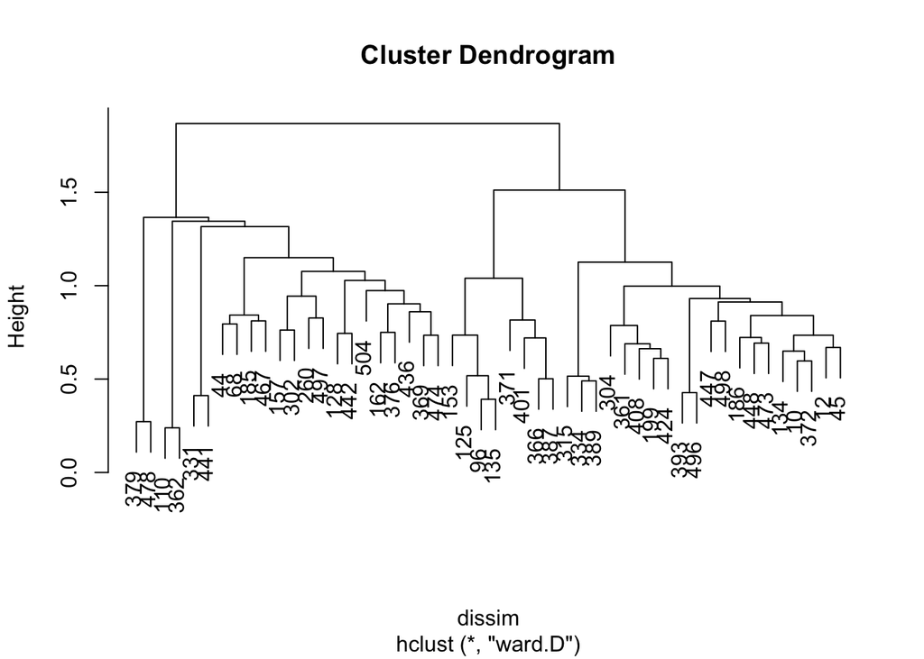

```r
# Note that to evaluate dissimilarity you will need to
# specify the method for calculating distance--check the
# documentation
dissim <- dist(mydocsDTM.mat, method = "cosine")

# You can also use this information to create a cluster plot
# with a built in plot function, again choosing a method. You
# could also add names to this manually with labels=names if
# you are not using built-in data

hcluster <- hclust(dissim, method = "ward.D")
plot(hcluster)
```

```r
# You may also care about word frequency

freq <- colSums(mydocsDTM.mat)
ordered <- order(freq)

freq[head(ordered)]
```

```
##     ability  acceptance accompanied   acquiring       acres      acting
##           1           1           1           1           1           1
```

```r
freq2 <- sort(colSums(mydocsDTM.mat), decreasing = T)
head(freq2, 10)
```

```
##    said    dlrs     pct     mln company     inc  shares    reut   stock
##     186     100      70      65      63      53      52      50      46
##    will
##      35
```

See the vignette linked above for how to graph word frequency using ggplot2. You can also restrict attention only to words that have frequency above a certain threshhold.

You may also be interested in the association between particular words, which is a beginning step toward topic analysis.

```r
# Fill in words in the second argument, set a lower bound for
# correlation
findAssocs(mydocsDTM, "good", corlimit = 0.75)
```

```
## $good
##        ability    accompanied       activity          along     analytical
##           1.00           1.00           1.00           1.00           1.00
##          arena       believes         better            big         bilion
##           1.00           1.00           1.00           1.00           1.00
##           book          boost       boosting     calculated capitalization
##           1.00           1.00           1.00           1.00           1.00
##         center        command       comments     components     constitute
##           1.00           1.00           1.00           1.00           1.00
##       contrary   contributing      disagreed   divestitures       dividend
##           1.00           1.00           1.00           1.00           1.00
##      elevating      endeavors       enormous       exposure           fact
##           1.00           1.00           1.00           1.00           1.00
##        fetched           fuel       globally           goes          going
##           1.00           1.00           1.00           1.00           1.00
##        heavily          heavy         helped      investing        jeffery
##           1.00           1.00           1.00           1.00           1.00
##          kinds         lesser          lewis           lift         lipper
##           1.00           1.00           1.00           1.00           1.00
##           mark          might         others       outlined      partially
##           1.00           1.00           1.00           1.00           1.00
##     percentage    performance         perrin       preclude        premium
##           1.00           1.00           1.00           1.00           1.00
##       probably     questioned      realistic        reduced           road
##           1.00           1.00           1.00           1.00           1.00
##          rumor          split       suggests          takes           talk
##           1.00           1.00           1.00           1.00           1.00
##        thereby         theyre         theyve         travel           true
##           1.00           1.00           1.00           1.00           1.00
##        tuesday    undervalued        unhappy     valuations      variation
##           1.00           1.00           1.00           1.00           1.00
##         volume          water      yesterday        reflect         market
##           1.00           1.00           1.00           0.95           0.91
##    eckenfelder        partial          place         strong      operating
##           0.89           0.89           0.89           0.89           0.87
##        spinoff         higher           make          since     profitable
##           0.85           0.81           0.81           0.81           0.75
```

If you’re interested in more complex topic model designs, check out the [`topicmodels`](https://cran.r-project.org/web/packages/topicmodels/vignettes/topicmodels.pdf) package. There are other packages like `tm` that you might want to explore as well, including `qdap`. See [this vignette](https://anythingbutrbitrary.blogspot.com/2014/01/statistics-meets-rhetoric-text-analysis.html) for more details.

### tidytext

Much of the syntax in the above functions will be familiar, even if the operations are not. The `sort`, `head`, and `plot` commands, as well as optional arguments and the regular expressions component weave in techniques that you have already learned. Yet as with many tasks in R, there is more than one way to perform text analysis. Many additional packages and functions build on `tm`, but another option is to approach text analysis through the language of `dplyr` using the [`tidytext` package](https://cran.r-project.org/web/packages/tidytext/tidytext.pdf).

Here again we will use a built-in dataset, this time with 2,246 Associated Press articles from the `topicmodels` package, to walk through the major functions in the package. The same steps apply as above, however, if your data are not already in a corpus format.

```r
library(topicmodels)
data("AssociatedPress", package = "topicmodels")

AssociatedPress
```

```
## <<DocumentTermMatrix (documents: 2246, terms: 10473)>>
## Non-/sparse entries: 302031/23220327
## Sparsity           : 99%
## Maximal term length: 18
## Weighting          : term frequency (tf)
```

You can “clean up” these data in a single line of code. Because the AssociatedPress data are already in a DocumentTermMatrix format, you don’t need to separate out by word, but you could do that with `unnest_tokens` if your data are not structured this way. Note that `unnest_tokens` also allows you to change the ngram for your analysis–that is, how many words or word segments are evaluated by comparison. For example if your ngram is 2, you are evaluating 2-word phrases.

```r
tidied <- tidy(AssociatedPress)
tidied
```

```
## # A tibble: 302,031 × 3
##    document       term count
##       <int>      <chr> <dbl>
## 1         1     adding     1
## 2         1      adult     2
## 3         1        ago     1
## 4         1    alcohol     1
## 5         1  allegedly     1
## 6         1      allen     1
## 7         1 apparently     2
## 8         1   appeared     1
## 9         1   arrested     1
## 10        1    assault     1
## # ... with 302,021 more rows
```

Note that using `grep` and other subsetting techniques we have explored, you can also narrow down what documents you want to look at within your broader set of texts. For example, if you only wanted to include articles that mentioned government actions or actors, you might want to select based on whether the document includes words like “government” or “president” *before* you tidy your text.

```r
selection <- "government|president"
final.docs <- mydocs[grepl(selection, mydocs$text), ]
```

You can perform similar tasks to the ones we did above with `tm` using `dplyr` syntax, such as removing stopwords, stemming, and obtaining word counts:

```r
data("stop_words")

cleaned <- tidied %>% anti_join(stop_words, by = c(term = "word"))

cleaner <- cleaned %>% mutate(word = wordStem(term))

cleaner %>% count(word, sort = TRUE)
```

```
## # A tibble: 6,722 × 2
##      word     n
##     <chr> <int>
## 1  report  1144
## 2  nation  1061
## 3  offici   935
## 4    time   878
## 5   peopl   872
## 6  presid   870
## 7     dai   833
## 8  govern   773
## 9    call   760
## 10   week   748
## # ... with 6,712 more rows
```

With these cleaned data, and with similar `join` syntax, we can also do other operations, such as sentiment analysis. You have several sentiment lexicons to choose from, but for this example we will simply use `bing`.

```r
ap_sentiments <- cleaner %>% inner_join(get_sentiments("bing"),
    by = c(term = "word"))

ap_sentiments
```

```
## # A tibble: 27,068 × 5
##    document     term count     word sentiment
##       <int>    <chr> <dbl>    <chr>     <chr>
## 1      1689      bug     5      bug  negative
## 2      2141      bug     1      bug  negative
## 3      1489 disarray     1 disarrai  negative
## 4      1507 disarray     1 disarrai  negative
## 5      1631 disarray     1 disarrai  negative
## 6      2013 disarray     1 disarrai  negative
## 7      2101 disarray     2 disarrai  negative
## 8      2219 disarray     1 disarrai  negative
## 9      1287   uphold     1   uphold  positive
## 10     1394   uphold     1   uphold  positive
## # ... with 27,058 more rows
```

Check out [this vignette](https://cran.r-project.org/web/packages/tidytext/vignettes/tidying_casting.html) for more on `tidytext` techniques, as well as [this guide](http://juliasilge.com/blog/Life-Changing-Magic/), featuring Jane Austen novels, for a more in-depth look at how to handle different corpus structures and for discussions of plotting sentiment.

## More, different syntaxes: R as a front-end

Besides the divide in syntax between base R and the `tidyverse`, R can also be used in more advanced applications as a front-end to other software and languages.

### rPython

The [rPython package](https://cran.r-project.org/web/packages/rPython/index.html) allows you to run Python code directly through R. As is common with many adaptations of other languages or programs to R, the functions in this program will have syntax from R that runs code from another language or program. This is useful if you need a particular functionality of one program or language, but are most comfortable or familiar with R’s interface and syntax.

### RSelenium

[RSelenium](https://cran.r-project.org/web/packages/RSelenium/vignettes/RSelenium-basics.html) is a great example of this. If you are not familiar with Python syntax for scraping webpages, for example, or have a more complex scraping project that requires you to manipulate a website at the same time, you can invoke Selenium (a java-based program) through R to do the necessary tasks. Note that to do this, you may want to run a Docker container. Instructions on how to do that are in the linked vignette above.

### Rcpp

The [Rcpp package](https://cran.r-project.org/web/packages/Rcpp/index.html) allows you to leverage both R and C++ syntaxes and libraries. This can be particularly useful as you optimize computationally intensive model estimation, or for creating your own packages. Read through the explanation in [Advanced R](http://adv-r.had.co.nz/Rcpp.html) for more.